# Midterm

Ranjith Gangam

November 27, 2015

Summary:

### Reading data

```r
rm(list=ls())
Flight_Data_full <- read.csv("D:/MS_documents/Meng/DAM/midterm/Landing.csv",h=T)
nrow(Flight_Data_full)
```

```
## [1] 800
```

### Data preprocessing

Aircraft type is Qualitative variable. Converting it to indicator variable.

```r
#creating dummy variable
Flight_Data_full$aircraft=1*(Flight_Data_full$aircraft=="boeing")

Flight_Data_full[is.na(Flight_Data_full)] <- 0

Flight_Data <- Flight_Data_full[ which(Flight_Data_full$speed_air> 30),]
Flight_Data <- Flight_Data[ which(Flight_Data$speed_air<140),]
cor(Flight_Data$speed_ground,Flight_Data$speed_air)
```

```
## [1] 0.9889627
```

### Visualising data

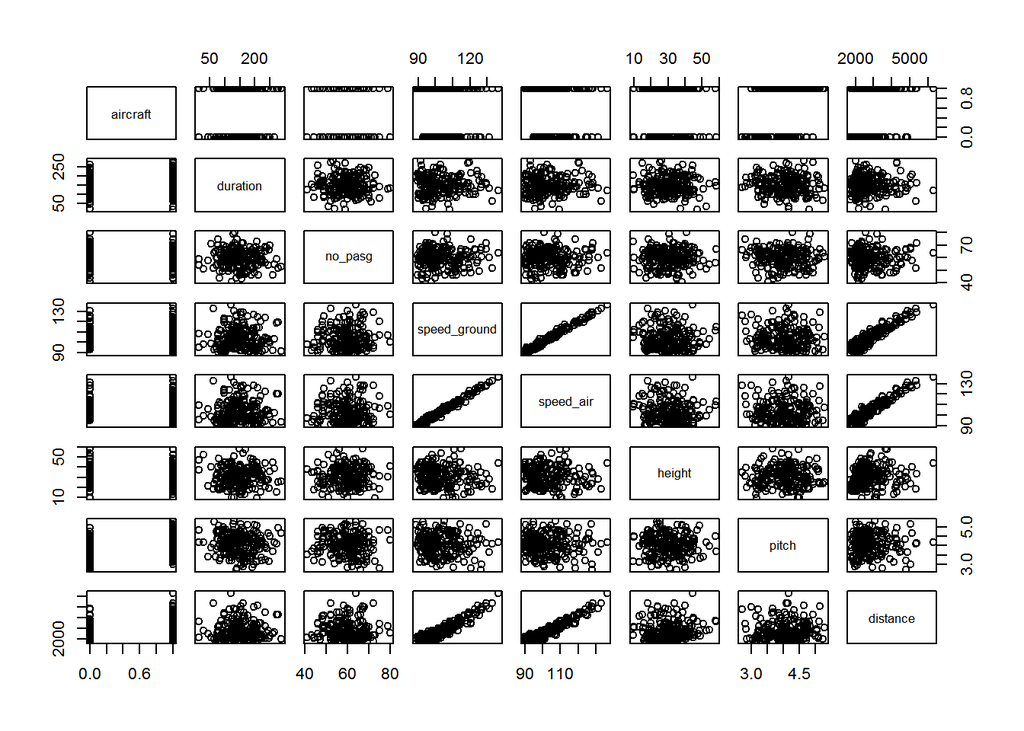

```r
plot(Flight_Data)
```

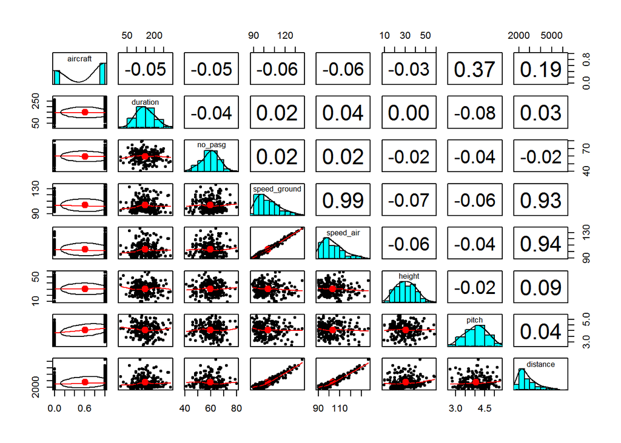

```r
library(psych)
pairs.panels(Flight_Data)
```

Pairs panels gives plots with correlation value. From the plot we can see that speed ground and speed air strongly correlated to each other and they are correlated with distance. It means they plan main role in deciding distance when compared to others.

### Limiting dataset to acceptable limits

```r
Flight_Data <- Flight_Data_full[which(Flight_Data_full$duration >40),]

Flight_Data <- Flight_Data[ which(Flight_Data$speed_ground> 30),]
Flight_Data <- Flight_Data[ which(Flight_Data$speed_ground<140),]
Flight_Data <- Flight_Data[ which(Flight_Data$height>6),]
Flight_Data <- Flight_Data[ which(Flight_Data$distance<6000),]
```

### Model with ground speed

```r
Model <- lm(distance ~ speed_ground, data=Flight_Data)
summary(Model)$coeff
```

```
##                 Estimate Std. Error   t value      Pr(>|t|)
## (Intercept)  -1766.75731 69.7769304 -25.32008 1.129579e-103
## speed_ground    41.53656  0.8525159  48.72233 1.060591e-238
```

```r
summary(Model)$r.squared
```

```
## [1] 0.7529232
```

```r
summary(Model)$adj.r.squared
```

```
## [1] 0.752606
```

```r
anova(Model)
```

```
## Analysis of Variance Table
##
## Response: distance
##               Df    Sum Sq   Mean Sq F value    Pr(>F)
## speed_ground   1 480561689 480561689  2373.9 < 2.2e-16 ***
## Residuals    779 157699570    202438
## ---
## Signif. codes:  0 '***' 0.001 '**' 0.01 '*' 0.05 '.' 0.1 ' ' 1
```

Model with speed ground has significant t values(greater than 2) for intercept and slope. Rsquare is 0.75. It also has large F value.

### Model with data transformation

There is a little curve in distance and speed ground plot. so here we are checking the necessity of data transformation.

```r
Model <- lm(log(distance) ~ speed_ground, data=Flight_Data)
summary(Model)$coeff
```

```
##                Estimate   Std. Error   t value      Pr(>|t|)
## (Intercept)  5.12065554 0.0482857082 106.04909  0.000000e+00
## speed_ground 0.02587195 0.0005899419  43.85508 1.334411e-212
```

```r
summary(Model)$r.squared
```

```
## [1] 0.7117236
```

```r
summary(Model)$adj.r.squared
```

```
## [1] 0.7113535
```

```r
anova(Model)
```

```
## Analysis of Variance Table
##
## Response: log(distance)
##               Df  Sum Sq Mean Sq F value    Pr(>F)
## speed_ground   1 186.443 186.443  1923.3 < 2.2e-16 ***
## Residuals    779  75.517   0.097
## ---
## Signif. codes:  0 '***' 0.001 '**' 0.01 '*' 0.05 '.' 0.1 ' ' 1
```

After transformation R square value went down to 0.71 from 0.75. t values are significant. But transformation did not improve any explanatory power of model.

Adding speed air to model along with ground . first we are preprocessing speed air data.

```r
Flight_Data_full[is.na(Flight_Data_full)] <- 0

Flight_Data_air <- Flight_Data_full[ which(Flight_Data_full$speed_air> 30),]
Flight_Data_air <- Flight_Data_air[ which(Flight_Data_air$speed_air<140),]
```

### Model with speed_air and speed_ground

we know by correlation value speed ground and air together gives multi collinearity, But it is cross checked here

```r
cor(Flight_Data_air$speed_ground,Flight_Data_air$speed_air)
```

```
## [1] 0.9889627
```

```r
Model <- lm(distance ~ speed_ground + speed_air, data=Flight_Data_air)
summary(Model)
```

```
##
## Call:
## lm(formula = distance ~ speed_ground + speed_air, data = Flight_Data_air)
##
## Residuals:
##     Min      1Q  Median      3Q     Max
## -838.37 -187.97    6.08  207.82  860.03
##
## Coefficients:
##              Estimate Std. Error t value Pr(>|t|)
## (Intercept)  -5577.23     208.25 -26.781  < 2e-16 ***
## speed_ground   -13.37      13.26  -1.009    0.314
## speed_air       94.22      13.48   6.988 4.27e-11 ***
## ---
## Signif. codes:  0 '***' 0.001 '**' 0.01 '*' 0.05 '.' 0.1 ' ' 1
##
## Residual standard error: 283.5 on 196 degrees of freedom
## Multiple R-squared:  0.893,  Adjusted R-squared:  0.8919
## F-statistic: 817.7 on 2 and 196 DF,  p-value: < 2.2e-16
```

```r
anova(Model)
```

```
## Analysis of Variance Table
##
## Response: distance
##               Df    Sum Sq   Mean Sq  F value    Pr(>F)
## speed_ground   1 127488575 127488575 1586.616 < 2.2e-16 ***
## speed_air      1   3923273   3923273   48.826 4.266e-11 ***
## Residuals    196  15749088     80352
## ---
## Signif. codes:  0 '***' 0.001 '**' 0.01 '*' 0.05 '.' 0.1 ' ' 1
```

```r
library(car)
vif(Model)
```

```
## speed_ground    speed_air
##     45.55219     45.55219
```

Now multicollinearity issue arised. for same reason t value for speed ground -1.0086639 is small even though F value is large. Finally VIF confirms this with value of 45.

### Model with speed_ground and height

```r
cor(Flight_Data$speed_ground,Flight_Data$height)
```

```
## [1] -0.05167181
```

```r
Model <- lm(distance ~ speed_ground + height, data=Flight_Data)
```

We see that r square value is improved to 0.7750514

```r
summary(Model)$coeff
```

```
##                 Estimate Std. Error    t value      Pr(>|t|)
## (Intercept)  -2217.42835 84.2158504 -26.330297 9.465401e-110
## speed_ground    41.90500  0.8150562  51.413628 1.994584e-252
## height          13.83449  1.5813985   8.748264  1.328870e-17
```

```r
summary(Model)$r.squared
```

```
## [1] 0.7750514
```

```r
summary(Model)$adj.r.squared
```

```
## [1] 0.7744732
```

```r
anova(Model)
```

```
## Analysis of Variance Table
##
## Response: distance
##               Df    Sum Sq   Mean Sq  F value    Pr(>F)
## speed_ground   1 480561689 480561689 2604.036 < 2.2e-16 ***
## height         1  14123617  14123617   76.532 < 2.2e-16 ***
## Residuals    778 143575953    184545
## ---
## Signif. codes:  0 '***' 0.001 '**' 0.01 '*' 0.05 '.' 0.1 ' ' 1
```

```r
vif(Model)
```

```
## speed_ground       height
##     1.002677     1.002677
```

### Model with speed_ground,height,pitch

```r
cor(Flight_Data$speed_ground,Flight_Data$pitch)
```

```
## [1] -0.05167034
```

```r
Model <- lm(distance ~ speed_ground + height + pitch, data=Flight_Data)
```

```r
summary(Model)$coeff
```

```
##                 Estimate  Std. Error    t value      Pr(>|t|)
## (Intercept)  -2986.99471 142.8685283 -20.907297  2.349918e-77
## speed_ground    42.16627   0.7947673  53.054864 1.578672e-260
## height          13.50854   1.5409036   8.766632  1.148273e-17
## pitch          189.00377  28.7303668   6.578537  8.726063e-11
```

```r
summary(Model)$r.squared
```

```
## [1] 0.7869195
```

```r
summary(Model)$adj.r.squared
```

```
## [1] 0.7860968
```

```r
anova(Model)
```

```
## Analysis of Variance Table
##
## Response: distance
##               Df    Sum Sq   Mean Sq  F value    Pr(>F)
## speed_ground   1 480561689 480561689 2745.542 < 2.2e-16 ***
## height         1  14123617  14123617   80.691 < 2.2e-16 ***
## pitch          1   7574949   7574949   43.277 8.726e-11 ***
## Residuals    777 136001005    175033
## ---
## Signif. codes:  0 '***' 0.001 '**' 0.01 '*' 0.05 '.' 0.1 ' ' 1
```

```r
vif(Model)
```

```
## speed_ground       height        pitch
##     1.005187     1.003715     1.003715
```

We see that r square value is improved to 0.7869195

Here aircraft is added

```r
cor(Flight_Data$speed_ground,Flight_Data$pitch)
```

```
## [1] -0.05167034
```

```r
Model <- lm(distance ~ speed_ground + height+ pitch + aircraft, data=Flight_Data)
summary(Model)$coeff
```

```
##                 Estimate  Std. Error     t value      Pr(>|t|)
## (Intercept)  -2603.38718 121.6341260 -21.4034274  3.108979e-80
## speed_ground    42.56134   0.6667019  63.8386436 4.420681e-311
## height          14.24183   1.2925514  11.0183831  2.480889e-26
## pitch           19.64746  25.8324908   0.7605715  4.471441e-01
## aircraft       489.21446  26.9568133  18.1480820  1.277804e-61
```

```r
summary(Model)$r.squared
```

```
## [1] 0.8504094
```

```r
summary(Model)$adj.r.squared
```

```
## [1] 0.8496383
```

```r
anova(Model)
```

```
## Analysis of Variance Table
##
## Response: distance
##               Df    Sum Sq   Mean Sq  F value    Pr(>F)
## speed_ground   1 480561689 480561689 3905.782 < 2.2e-16 ***
## height         1  14123617  14123617  114.790 < 2.2e-16 ***
## pitch          1   7574949   7574949   61.566 1.419e-14 ***
## aircraft       1  40523097  40523097  329.353 < 2.2e-16 ***
## Residuals    776  95477907    123039
## ---
## Signif. codes:  0 '***' 0.001 '**' 0.01 '*' 0.05 '.' 0.1 ' ' 1
```

```r
vif(Model)
```

```
## speed_ground       height        pitch     aircraft
##     1.006260     1.004697     1.154358     1.153060
```

```r
Model <- lm(distance ~ speed_ground + height + aircraft + no_pasg, data=Flight_Data)
summary(Model)$coeff
```

```
##                  Estimate  Std. Error     t value      Pr(>|t|)
## (Intercept)  -2429.798171 121.7737334 -19.9533849  8.054024e-72
## speed_ground    42.543136   0.6661271  63.8663926 3.329804e-311
## height          14.329453   1.2919937  11.0909620  1.233524e-26
## aircraft       495.950591  25.1390775  19.7282733  1.570902e-70
## no_pasg         -1.652378   1.6701003  -0.9893887  3.227814e-01
```

t value is less than 2 for number of passengers. therefore it is insignificant.

```r
Model <- lm(distance ~ speed_ground + height + aircraft + duration, data=Flight_Data)
summary(Model)$coeff
```

```
##                   Estimate Std. Error     t value      Pr(>|t|)
## (Intercept)  -2.536246e+03 82.7812189 -30.6379379 9.777670e-136
## speed_ground  4.255014e+01  0.6673904  63.7559991 1.028595e-310
## height        1.428048e+01  1.2919411  11.0535042  1.769863e-26
## aircraft      4.968445e+02 25.1727058  19.7374287  1.392422e-70
## duration      4.949316e-02  0.2604602   0.1900219  8.493416e-01
```

t value is less than 2 for duration. therefore it is insignificant.

### Model with speed ground, height and aircraft

```r
Model <- lm(distance ~ speed_ground + height + aircraft, data=Flight_Data)

summary(Model)$coeff
```

```
##                 Estimate Std. Error   t value      Pr(>|t|)
## (Intercept)  -2528.02077 70.5193199 -35.84863 7.519875e-167
## speed_ground    42.54371  0.6661178  63.86814 1.989697e-311
## height          14.28239  1.2911002  11.06219  1.619498e-26
## aircraft       496.62096 25.1296036  19.76239  9.661475e-71
```

```r
summary(Model)$r.squared
```

```
## [1] 0.8502979
```

```r
summary(Model)$adj.r.squared
```

```
## [1] 0.8497199
```

```r
anova(Model)
```

```
## Analysis of Variance Table
##
## Response: distance
##               Df    Sum Sq   Mean Sq F value    Pr(>F)
## speed_ground   1 480561689 480561689 3907.90 < 2.2e-16 ***
## height         1  14123617  14123617  114.85 < 2.2e-16 ***
## aircraft       1  48026872  48026872  390.55 < 2.2e-16 ***
## Residuals    777  95549081    122972
## ---
## Signif. codes:  0 '***' 0.001 '**' 0.01 '*' 0.05 '.' 0.1 ' ' 1
```

```r
vif(Model)
```

```
## speed_ground       height     aircraft
##     1.005043     1.002986     1.002587
```

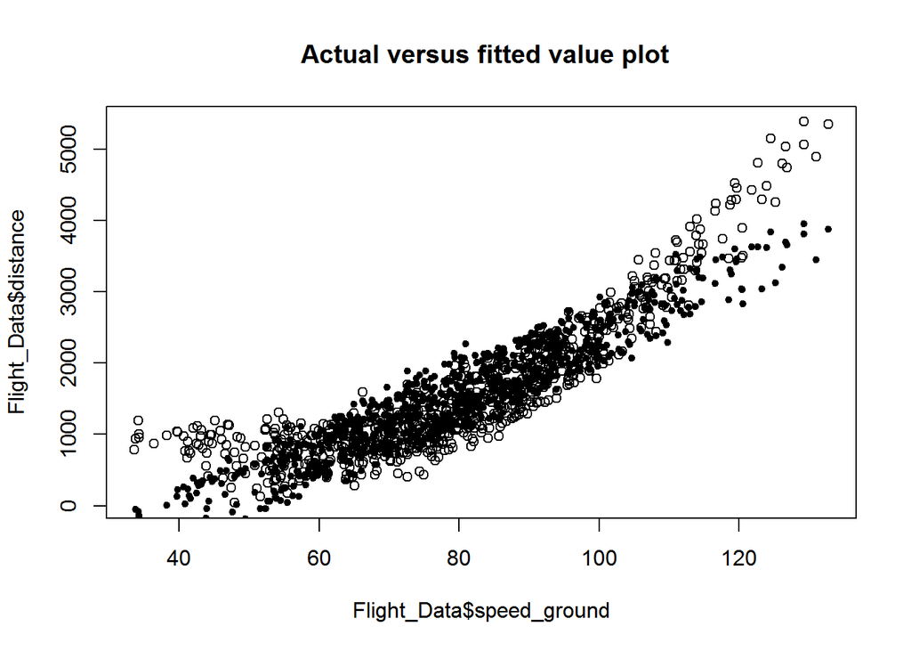

```r
plot(Flight_Data$speed_ground,Flight_Data$distance, main=" Actual versus fitted value plot")
points(Flight_Data$speed_ground,Model$fitted.values,pch=20)
```

```r
SSRes=sum((Model$residuals)^2)
SSR = anova(Model)[2,2]+ anova(Model)[1,2] + anova(Model)[3,2]

F0 = summary(Model)$fstatisti[1]
F=qf(.95, df1=2, df2=777)
F0
```

```
##    value
## 1471.102
```

```r
F
```

```
## [1] 3.007312
```

F0 value is greater than F. All coefficients are significant

This model has 85% explanatory power. SSRes = 95549081 SSR =542712178 SSR gives how much variation of response variable is explained by model. This value is big when compared to variation not explained in model

```r
vif(Model)
```

```
## speed_ground       height     aircraft
##     1.005043     1.002986     1.002587
```

VIF value is around one. so no multicollinearity exists

Final model isDistance = -2528+ 42.54 * speed_ground + 14.28 * height +496.62 * aircaraft.

TO compare which parameter impacts more on distance standardising is done here.

```r
life_unit_normal1=as.data.frame(apply(Flight_Data,2,function(x){(x-mean(x))/sd(x)}))

Model_unit_normal <- lm(distance ~ speed_ground+height+aircraft, data=life_unit_normal1)

Model_unit_normal$coefficients
```

```
##  (Intercept) speed_ground       height     aircraft
## 4.135608e-18 8.887511e-01 1.537772e-01 2.746654e-01
```

By above values speed ground has more impact when compared to others

Therefore final model is  
Distance = -2528+ 42.54 * speed_ground + 14.28 * height +496.62 * aircaraft.

It means for one mile increase in speed ground distance is increased by 42.54 feet rovided height and aircraft make are constants. similar interpretation for height and aircraft type.